# Money Ball

### Andrew Hong CMSC320

Import the necessary libraries

```python
import sqlite3
import pandas as pd
import matplotlib.pyplot as plt
import statistics as stat
import numpy as np
import requests
from bs4 import BeautifulSoup
```

```python
# establish connection to sqlite file
sqlite_file = 'lahman2014.sqlite'
conn = sqlite3.connect(sqlite_file)
```

## Part 1: Wrangling

### Problem 1

Two tables were utilized: the Salaries table and Teams table. From the Salaries table, the year, team name, league, and calculated sum salary were obtained and from the Teams table, the games played, wins, losses, and calculated win percentage was obtained. An inner join was utilized so that rows across both tables were grouped together by matching year and team name. Rows were grouped by a common year and team name to view trends for teams by year

Inner join ensures that rows extracted from the Teams and Salaries table share a common year and team name. This means that any extraneous teams or years that are NOT found in both tables will not be included, which can useful for missing data.

Within the information collected, there was no missing data found. In the case of missing values, np.nan (NaN) would be used to replace any missing numerical values and 'None' would be used to replace any character values.

```python
# The number of wins and games played must be casted to float in the calculation for 'Winning' or the resulting answer
# will be an integer
salary_query = "SELECT Salaries.yearID, Salaries.teamID, Salaries.lgID, sum(Salaries.salary) as total_payroll, \
Teams.G, Teams.W, Teams.L, CAST(Teams.W as FLOAT)/CAST(Teams.G as FLOAT)*100.0 as Winning \
FROM Salaries INNER JOIN Teams ON Salaries.yearID = Teams.yearID AND Salaries.teamID = Teams.teamID \
GROUP BY Salaries.yearID, Salaries.teamID"
```

```python
# Read SQL query and store result in team_salaries
team_salaries = pd.read_sql(salary_query, conn)
```

## Part 2: Exploratory Data Analysis

### Problem 2

To view the payroll trends by team, we first need to obtain the payroll from 1990-2014. To start we sort the rows in the dataframe by yearID and teamID for easier iteration.

```python
# sort dataframe by yearID and teamID so values are grouped together
team_salaries = team_salaries.sort_values(by=['yearID', 'teamID'])
```

```python
# set standard size for figures
plt.rcParams["figure.figsize"]=15,15
```

A line graph was used to plot the data as the x-values are continuous and it's easy to view trends in payroll. For each unique team in the dataframe between the years 1990-2014, the yearID (x-values) and total_payroll (y-values) were obtained and converted to a list. Then they were both plotted onto the axis.

There are over 35 unique teams, so eventually the default colors used will loop over, causing duplicate line colors. To mitigate this, I created a list of patterns that would repeat a pattern every third iteration. This in turn triples the amount of unique line designs.

I created a separate function called plot_team for this. This reduced the amount of code required and reduces repetative code.

```python
# list of patterns
patterns = ['dashed', 'dotted', 'dashdot']
# this function plots the payroll trends for a given team
def plot_team(team_name, index, ax):
    # obtain years for a given team
    x = (team_salaries[(team_salaries['teamID'] == team_name) & (team_salaries['yearID'] >= 1990)])['yearID'].tolist()
    # obtain total payroll for a given team
    y = (team_salaries[(team_salaries['teamID'] == team_name) & (team_salaries['yearID'] >= 1990)])['total_payroll'].tolist()
    # plot on axis
    ax.plot(x, y, linestyle = patterns[index], label=team_name)
```

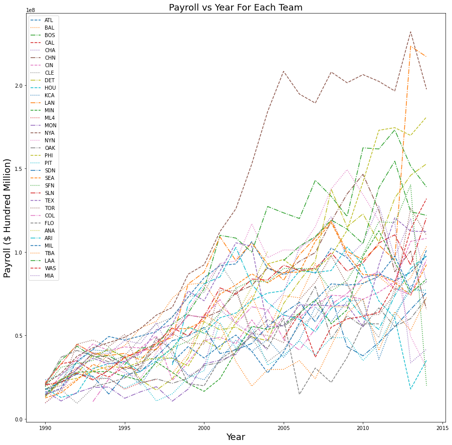

```python
# create figure and axes
fig, ax = plt.subplots()
# clear axis to ensure nothing extra was added from beforehand
ax.clear()
# index is used to iterate through pattern
index = 0
# for each unique team in the dataframe, plot the payroll trends
for team in team_salaries.teamID.unique():
    # mod 3 is used to iterate through pattern list
    plot_team(team, index % 3, ax)
    # increment index
    index += 1
# add titles
ax.set_title("Payroll vs Year For Each Team", fontsize = 18)
ax.set_xlabel('Year', fontsize = 18)
ax.set_ylabel('Payroll ($ Hundred Million)', fontsize = 18)
ax.legend()
# display result
```

### Problem 3

There are two major values I want to plot: the mean payroll and standard deviation payroll for each year. This will help highlight the increase in payroll value and spread. I used a bar graph as it would allow me to use error bars to represent the standard deviation. Also, it provides visually distinct differences between mean payroll values. The black bars represent the standard deviation (+- 1 SD). I believe that this graph type would best represent the trends.

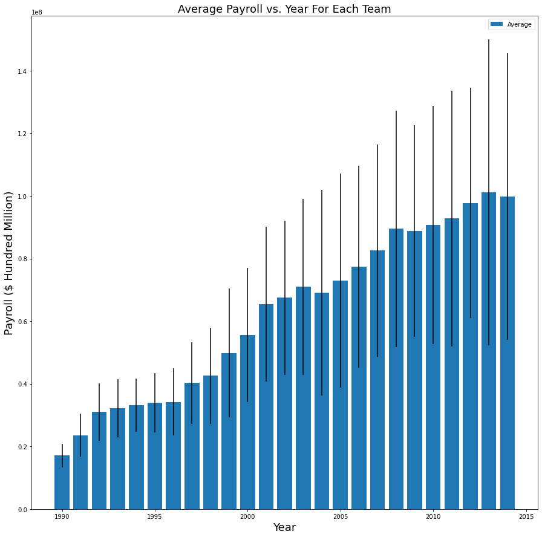

```python
# clear axis to ensure that no extra data is being plotted
ax.clear()
# set initial year to 1990
year = 1990
# lists are used to collect the calculated standard deviation and average for each year
year_salaries_average_list = []
year_salaries_stdev_list = []
# used to collect years
year_list = []
while (year < 2015):
    # get values where 'yearID' equals 'year' and convert to list
    year_salaries = (team_salaries[team_salaries['yearID'] == year])['total_payroll'].tolist()
    # calculcate average
    average = sum(year_salaries)/len(year_salaries)
    # calculate mean using statistics module
    stdev = stat.stdev(year_salaries)
    # add values to appropriate lists
    year_list.append(year)
    year_salaries_average_list.append(average)
    year_salaries_stdev_list.append(stdev)
    # increment year by 1
    year = year + 1
# add bar graph for average salary and have error bars set to the standard deviation
ax.bar(year_list, year_salaries_average_list, yerr = year_salaries_stdev_list, label = 'Average')
#ax.errorbar(year_list, year_salaries_stdev_list, label = 'Standard Deviation')
# add legend
ax.legend()
# add labels and titles
ax.set_title("Average Payroll vs. Year For Each Team", fontsize = 18)
ax.set_xlabel('Year', fontsize = 18)
ax.set_ylabel('Payroll ($ Hundred Million)', fontsize = 18)
# display fig
fig
```

The plot shows that as time increases, the average payroll increases. Also, the error bars are increasing in size, displaying the increase in spread over time as well.

### Problem 4

Next, the data was split into 5 periods. Because there are 25 years total (1990 - 2014), each period will be 5 years. Starting at 1989-1994 and increasing by 5 for each bin. For each time period, the average payroll for each team was calculcated and plotted on its own axis (1 axis for each time period).

Below is a function that gives a unique color and design for the scatter plot points for each unique team. This allows the user to distinguish between different teams on the plot and make additional conclusions about points.

```python
def get_plot_design(team):
    if team == 'ATL':
        return ('firebrick', 'o')
    if team == 'BAL':
        return ('firebrick', 's')
    if team == 'BOS':
        return ('firebrick', '1')
    if team == 'CAL':
        return ('lightsalmon', 'o')
    if team == 'CHA':
        return ('lightsalmon', 's')
    if team == 'CHN':
        return ('lightsalmon', '1')
    if team == 'CIN':
        return ('darkorange', 'o')
    if team == 'CLE':
        return ('darkorange', 's')
    if team == 'DET':
        return ('darkorange', '1')
    if team == 'HOU':
        return ('gold', 'o')
    if team == 'KCA':
        return ('gold', 's')
    if team == 'LAN':
        return ('gold', '1')
    if team == 'MIN':
        return ('yellow', 'o')
    if team == 'ML4':
        return ('yellow', 's')
    if team == 'MON':
        return ('yellow', '1')
    if team == 'NYA':
        return ('lawngreen', 'o')
    if team == 'NYN':
        return ('lawngreen', 's')
    if team == 'OAK':
        return ('lawngreen', '1')
    if team == 'PHI':
        return ('turquoise', 'o')
    if team == 'PIT':
        return ('turquoise', 's')
    if team == 'SDN':
        return ('turquoise', '1')
    if team == 'SEA':
        return ('dodgerblue', 'o')
    if team == 'SFN':
        return ('dodgerblue', 's')
    if team == 'SLN':
        return ('dodgerblue', '1')
    if team == 'TEX':
        return ('darkgreen', 'o')
    if team == 'TOR':
        return ('darkgreen', 's')
    if team == 'COL':
        return ('darkgreen', '1')
    if team == 'FLO':
        return ('blueviolet', 'o')
    if team == 'ANA':
        return ('blueviolet', 's')
    if team == 'ARI':
        return ('blueviolet', '1')
    if team == 'MIL':
        return ('deeppink', 'o')
    if team == 'TBA':
        return ('deeppink', 's')
    if team == 'LAA':
        return ('deeppink', '1')
    if team == 'WAS':
        return ('fuchsia', 'o')
    if team == 'MIA':
        return ('fuchsia', 's')
    return ('black','o')
```

A scatter plot was used to display the values from each time period. From there a line of best was generated to see if there was a trend.

Since different values are being plotted for each axis, one issue that can arise is that the range of the x-values and y-values on the axes can vary, resulting in misleading comparisons. To prevent this, sharey and sharex are both set to True so that each axes of the figure is the same. One consequence of this however, is that for some of the plots, the datapoints will be squished together.

For each of the scatter plots, I also calculated the r value to quantify how strong the correlation was between the two variables. A value closer to 1 indicates a strong positive direct relationship.

```
The r value between the years 1990.0 and 1994.0 is 0.3477448639893431
The r value between the years 1995.0 and 1999.0 is 0.7394512737896317
The r value between the years 2000.0 and 2004.0 is 0.550451389521479
The r value between the years 2005.0 and 2009.0 is 0.6772792521457237
The r value between the years 2010.0 and 2014.0 is 0.47553978736494984
```

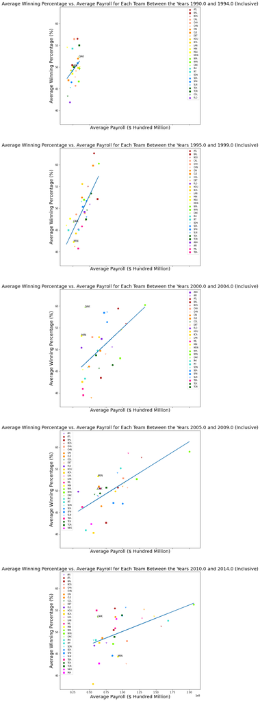

```python
# use pandas.cut to split into 5 bins
team_salaries['yearBins'] = pd.cut(team_salaries['yearID'], bins=[1989, 1994, 1999, 2004, 2009, 2014])
# create figure and axes
fig_cut, ax_cut = plt.subplots(5, figsize=(10, 50), sharey = True, sharex = True)
# set initial year to 1989
year = 1989.0
# i used to iterate through axes
i = 0
while year < 2014.0:
    # clear axis to make sure no extra values are included
    ax_cut[i].clear()
    # store mean values of win percentage and payroll for each time period
    average_payroll_list = []
    average_win_list = []
    # isolate rows where it has the matching Interval (i.e. time period) year is not inclusive
    isolated_df = team_salaries[team_salaries['yearBins'] == pd.Interval(year, year+5, closed = 'right')]
    for team in isolated_df.teamID.unique():
        # calculate mean winning percentage and payroll for each unique team in time period
        isolated_team_df = isolated_df[isolated_df['teamID'] == team]
        average_payroll = isolated_team_df['total_payroll'].mean()
        average_win = isolated_team_df['Winning'].mean()
        # plot and add labels
        col, mark = get_plot_design(team)
        ax_cut[i].scatter(average_payroll, average_win, label=team, marker=mark, color = col)
        ax_cut[i].set_title("Average Winning Percentage vs. Average Payroll for Each Team Between the Years " + str(year+1.0) + " and " + str(year+5.0) +" (Inclusive)", fontsize = 18)
        ax_cut[i].set_ylabel("Average Winning Percentage (%)", fontsize=18)
        ax_cut[i].set_xlabel("Average Payroll ($ Hundred Million)", fontsize=18)
        ax_cut[i].legend(prop={'size': 8})
        # only label 'OAK' or 'MIN' points as this is the main focus of the project
        # 'MIN' is used for the next question which is why I labeled it
        if (team == 'OAK' or team == 'MIN'):
            ax_cut[i].annotate(team, (average_payroll, average_win))
        # append values to list
        average_payroll_list.append(average_payroll)
        average_win_list.append(average_win)
    # generate line of best fit for each axis and plot
    m, b = np.polyfit(average_payroll_list, average_win_list, 1)
    a = np.asarray(average_payroll_list)
    ax_cut[i].plot(a, m*a + b)
    # calculate r value
    r = np.corrcoef(average_payroll_list, average_win_list)[0][1]
    print("The r value between the years " + str(year+1) + " and " + str(year+5) + " is " + str(r))
    # increment year by 5 and index by 1
    year += 5.0
    i += 1
# display figure
#fig_cut
```

### Question 2

There is overall a weak/moderate direct correlation between winning percentage and team payroll. The r values range from 0.3 to 0.7, supporting this claim. The plot with the strongest correlation is between 1995 and 1999.

A team with good spending efficiency will have a low payroll but high winning percentage, meaning they will be located at the top left of the plot. There are some teams that are overall good at spending such as 'MIN' who are almost consistetly have a high winning percentage using a low amount of payroll. However, out of all of the teams, 'OAK' had the best spending, with its most efficient spending occurring between the years 2000-2005. One can observe this from the fact that the point is in the top left of the plot.

The trends outlined in the project are reflected in the plots. Before 2000, OAK had an average efficiency (the OAK points are near the linear regression line). During 2000-2005, the efficiency was way above average. Following this, more teams experienced increased effiency (more points near the top left of the plot).

## Part 3: Data Transformation

### Problem 5

For a more accurate comparison between payroll between years, a standard payroll column was created. This is calculated by taking the payroll, subtracting by the average, and then dividing by the standard deviation. This is like calculating a z-score and provides a relative comparison between different payrolls.

```python
# used to access averages and SDs from the lists created from the previous problem
index = 0
# set initial value to NaN
team_salaries['standard_payroll'] = np.nan
# 25 is the last entry since there are 25 years
while index < 25:
    # lambda function used to calculate standardized value
    team_salaries['standard_payroll']=team_salaries.apply(lambda x: (x.total_payroll - year_salaries_average_list[index])/year_salaries_stdev_list[index] if x.yearID == year_list[index] else x.standard_payroll, axis = 1)
    # increment axis
    index = index + 1
```

### Problem 6

The years for the bins starts at 1989 since the first value is not included in the Interval. Like the previous figure, sharex and sharey are both set to True.

```
The r value between the years 1990.0 and 1994.0 is 0.345238724963088
0.345238724963088
The r value between the years 1995.0 and 1999.0 is 0.7520914549795458
0.7520914549795458
The r value between the years 2000.0 and 2004.0 is 0.5261628269112072
0.5261628269112072
The r value between the years 2005.0 and 2009.0 is 0.6769102253971212
0.6769102253971212
The r value between the years 2010.0 and 2014.0 is 0.45845676044918665
0.45845676044918665
```

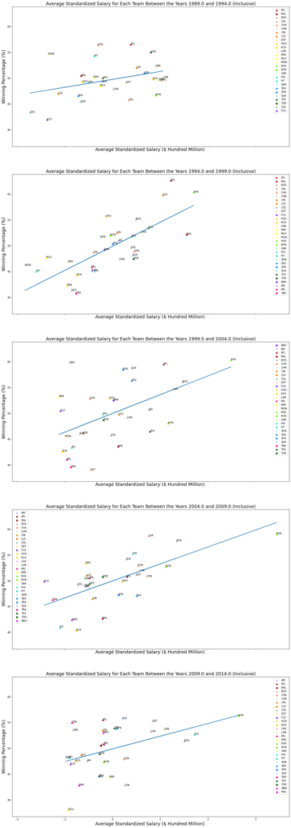

```python
team_salaries['yearBins'] = pd.cut(team_salaries['yearID'], bins=[1989, 1994, 1999, 2004, 2009, 2014])
fig_stan, ax_stan = plt.subplots(5, figsize=(20, 60), sharey = True, sharex = True)
# set initial year to 1989
year = 1989.0
# used to iterate through axes
i = 0
while year < 2014.0:
    # clear axis to make sure no extra values are included
    ax_stan[i].clear()
    # clear lists
    average_payroll_list = []
    average_win_list = []
    # get rows with matching bin, year is not inclusive
    isolated_df = team_salaries[team_salaries['yearBins'] == pd.Interval(year, year+5, closed = 'right')]
    for team in isolated_df.teamID.unique():
        # for each time period, get mean of winning percentage and standard payroll for each team and plot
        isolated_team_df = isolated_df[isolated_df['teamID'] == team]
        average_payroll = isolated_team_df['standard_payroll'].mean()
        average_win = isolated_team_df['Winning'].mean()
        col, mark = get_plot_design(team)
        ax_stan[i].scatter(average_payroll, average_win, label=team, marker=mark, color = col)
        #ax_stan[i].scatter(average_payroll, average_win, label=team, marker = shapes[shape_index%4])
        # add labels and append to list
        ax_stan[i].set_title("Average Standardized Salary for Each Team Between the Years " + str(year) + " and " + str(year+5.0) +" (Inclusive)", fontsize = 18)
        ax_stan[i].set_ylabel("Winning Percentage (%)", fontsize=18)
        ax_stan[i].set_xlabel("Average Standardized Salary ($ Hundred Million) ", fontsize=18)
        ax_stan[i].legend()
        ax_stan[i].annotate(team, (average_payroll, average_win))
        average_payroll_list.append(average_payroll)
        average_win_list.append(average_win)
    # generate line of best fit and plot
    m, b = np.polyfit(average_payroll_list, average_win_list, 1)
    a = np.asarray(average_payroll_list)
    r = np.corrcoef(average_payroll_list, average_win_list)[0][1]
    print("The r value between the years " + str(year+1) + " and " + str(year+5) + " is " + str(r))
    print(r)
    ax_stan[i].plot(a, m*a + b)
    # increment year by 5 and index by 1
    year += 5.0
    i += 1
#fig_stan
```

### Question 3

One major issue from problem 4 was that using a shared x and y axis range of values made it difficult to compare between time periods. Using the standardized payroll, it's much easier to compare plots between plots. The data points are centered around the 0 on the x-axis, making it easier to compare datapoints.

While the x range of values changed the appearance of the plot, the winning percentage remained the same, meaning that the same conclusions can still be made across problem 4 and 6. Before 2000, OAK had averge efficiency, the years 2000-2005 had very high effiency for OAK, and in the following years more teams experienced good efficiency.

### Problem 7

Instead of multiple plots, one single plot will be used so it's easier to determine a trend. Like the previous axis, a scatter plot will used along with a linear regression line. The 'OAK' datapoints are labeled as they are the main focus of the project and allows the reader to quickly observe its trends.

```
The r value 0.3860460082471542
```

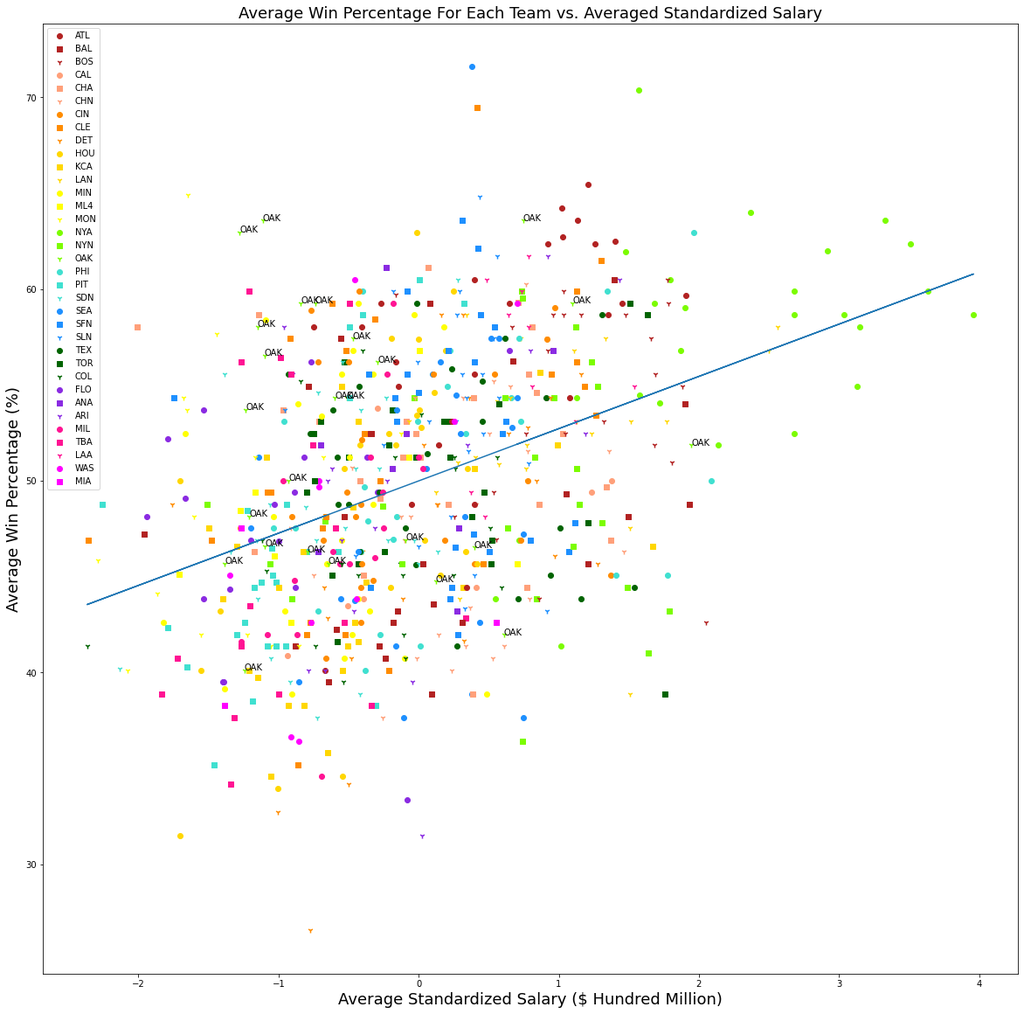

```python
fig_all, ax_all = plt.subplots(1,figsize=(20,20))
# clear axis
ax_all.clear()
# clear list
average_payroll_list = []
average_win_list = []
every_team = []
year = 1990
# used to iterate through marker designs
shape_index = 0
shapes = ['o', 's', '<', '1']
while year < 2015:
    isolated_df = team_salaries[team_salaries['yearID'] == year]
    for team in isolated_df.teamID.unique():
        # for each team, calculate mean winning percentage and payroll
        isolated_team_df = isolated_df[isolated_df['teamID'] == team]
        payroll = isolated_team_df.iloc[0]['standard_payroll']
        win = isolated_team_df.iloc[0]['Winning']
        # plot and set titles
        col, mark = get_plot_design(team)
        #ax_all.scatter(average_payroll, average_win, label=team, marker=mark, color = col)
        if team in every_team:
            ax_all.scatter(payroll, win, marker = mark, color = col)
        else:
            ax_all.scatter(payroll, win, label=team, marker = mark, color = col)
            every_team.append(team)
        # only annotate for OAK since that is our main focus for this project
        if (team == 'OAK'):
            ax_all.annotate(team, (payroll, win))
        #ax_all.scatter(payroll, win, label=team, marker = mark, color = col)
        ax_all.set_title("Average Win Percentage For Each Team vs. Averaged Standardized Salary", fontsize = 18)
        ax_all.set_xlabel("Average Standardized Salary ($ Hundred Million)", fontsize=18)
        ax_all.set_ylabel("Average Win Percentage (%)", fontsize=18)
        ax_all.legend()
        # append to list
        average_payroll_list.append(payroll)
        average_win_list.append(win)
    year += 1
# create and plot linear regression line
m, b = np.polyfit(average_payroll_list, average_win_list, 1)
a = np.asarray(average_payroll_list)
r = np.corrcoef(average_payroll_list, average_win_list)[0][1]
print("The r value " + str(r))
ax_all.plot(a, m*a + b)
# display figure
```

The r value for this was found to be about 0.38, indicating a weak correlation between the win percentage and standardized salary. This shows that spending more money can lead to increased winning. However, it's not guranteed. Some teams are able to spend more money efficiently like Oakland.

### Problem 8

There were 2 additional columns added, expected_win, which represents the projected/expected winning percentage based on the linear regression, and efficiency, which represents how well a team spends their money. A positive value represnets good efficiency and vice-versa.

```python
team_salaries['expected_win'] = team_salaries.apply(lambda x: x.standard_payroll*2.5 + 50, axis = 1)
```

```python
team_salaries['efficiency'] = team_salaries.apply(lambda x: x.Winning - x.expected_win, axis = 1)
```

[figure not shown]

```python
fig_small, ax_small = plt.subplots()
```

This is a helper function that simply plots the efficiency vs the year (only > 1990) for a given team.

```python
def plot_efficiency(team, ax):
    # only want years > 1990
    team_df = team_salaries[(team_salaries['teamID'] == team) & (team_salaries['yearID'] >= 1990)]
    ax.plot(team_df['yearID'].tolist(), team_df['efficiency'].tolist(), label = team)
    ax.legend()
```

There were 5 teams plotted: Oakland, the New York Yankees, Boston, Atlanta, and Tampa Bay. Each of the datapoints for each of these teams was plotted.

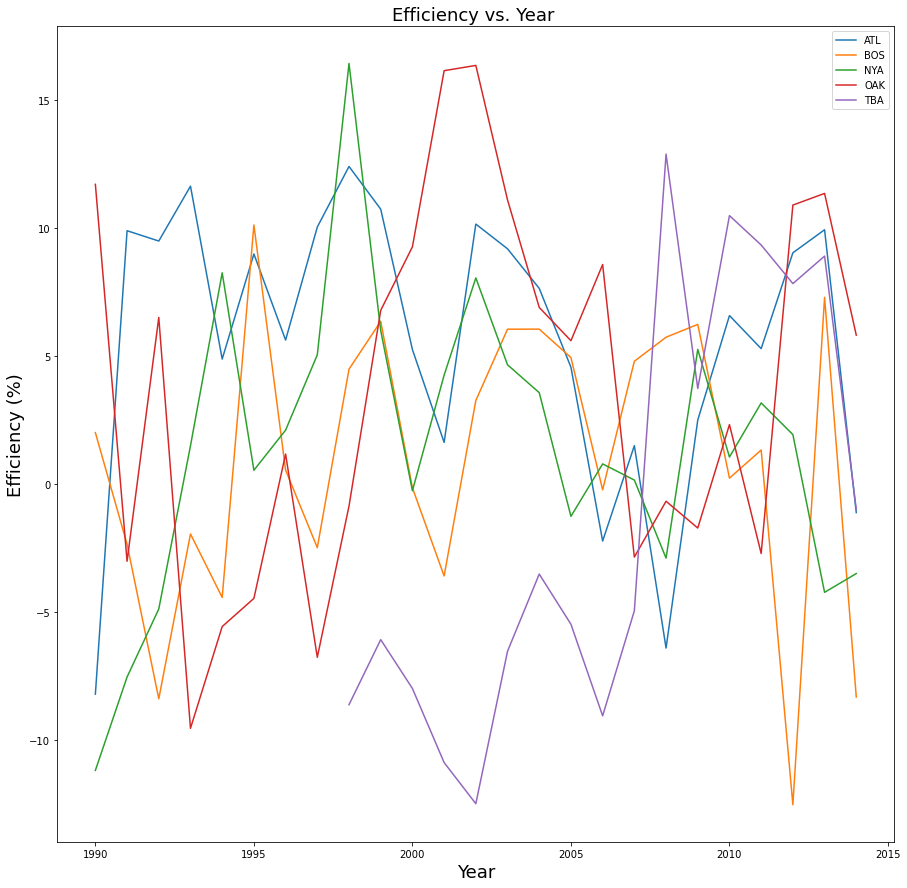

```python
ax.clear()
plot_efficiency('ATL', ax)
plot_efficiency('BOS', ax)
plot_efficiency('NYA', ax)
plot_efficiency('OAK', ax)
plot_efficiency('TBA', ax)
# add titles
ax.set_title("Efficiency vs. Year ", fontsize = 18)
ax.set_xlabel("Year", fontsize=18)
ax.set_ylabel("Efficiency (%)", fontsize=18)
# display fig
fig
```

### Question 4

Unlike the plots for question 2 and 3 where the data was broken into time periods of 5 years, this plot shows exact years where each team has good efficiency. Regions where the efficiency is greater than 0 are considered period of good efficiency. Although this efficiency can be observed in the plots for question 2 and 3 by observing the distance between the linear regression line and point on the plot, this plot quantifies that difference and visualizes it in on a graph. This allows for simpler and more convenient analysis to determine how good a team is at spending.

During the Moneyball period, the Oakland team had outstanding efficiency. At its peak, during the years 2001 and 2002, the team had an efficiency of over 16. This number reflects the effectiveness of their strategy. They were able to achieve an above average winning record while spending relatively little on their payroll.

As previousley stated, the plots from question 2 and 3 show that spending more money can generally lead to increased winning. However, it's not guranteed. Teams like Oakland were able to spend money more efficiently, leading to outstanding results. To get a more clear understanding of the data, a more detailed breakdown of the spending is required.

## Extra Credit

To obtain the data, there were two resources I used.

For the team statistics, I used the data from journalist [Sean Lahman](http://www.seanlahman.com/) . There is an updated [.csv](https://github.com/chadwickbureau/baseballdatabank/tree/master/core) file that contains data for teams up the 2020. This was much easier to work with as pandas provides a way to convert csv files into an sql table. I imported the file called "Teams.csv".

However, the data for the player salaries is only up to 2016. To get the salaries for the years 2015-2020. I found a table of team yearly salaries [here](http://www.stevetheump.com/Payrolls.htm)

First we need to create a SQL database. I created a connection to a new database called "UpdatedStats.db". It's placed in a try-catch statement in case the connection fails.

```python
try:
    conn = sqlite3.connect('UpdatedStats.db')
except Error as e:
    # print error if it fails
    print(e)
```

```python
# convert the csv file to a pandas DataFrame
read_teams = pd.read_csv("Teams.csv")
# add win percentage column and isolate only years > 1990
read_teams['Win_Percentage'] = read_teams.apply(lambda x: float(x.W)/float(x.G)*100.0, axis = 1)
read_teams = read_teams[read_teams['yearID'] >= 1990]
```

```python
read_teams.to_sql('Teams', conn, if_exists='replace', index = False)
```

```python
# establish a HTTP request for the webstie containing the salary tables
menu = requests.get('http://www.stevetheump.com/Payrolls.htm')
# convert to BeautifulSoup object and look for table element
soup = BeautifulSoup(menu.text, features="lxml")
table = soup.find_all('table')
```

This provides the tables of salaries for each of the years. Index 2 is the year 2020 and each increment represents one year less. So for example, index 3 is the year 2019. Since each table is formatted differently, the parsing required is different for each one.

```python
# for 2020
# master_list is the list of each row of the salaries dataframe
master_list = []
# row represents one row
row = []
temp = table[2].text.split('\n')
temp = list(filter(None, temp))
for i in range(len(temp)):
    # conditions are used to determine if its total payroll column
    # i - 4 is the # column, just used to make sure that total payroll column is being used
    if '$' in temp[i] and temp[i-4] == '30':
        row.append(2020)
        # i-5 is team name
        row.append(temp[i-5])
        # do not want $ or , when casting
        row.append(float(temp[i][1:len(temp[i]) -1].replace(',', '')))
        master_list.append(row)
        row = []
```

The total payroll for 2019 should be the sum of the sub payroll columns which is why they are added together.

```python
# for 2019
row = []
temp = table[3].text.split('\n')
for i in range(len(temp)):
    # conditions are used to determine if its total payroll column
    # i - 2 team name
    if '$' in temp[i] and temp[i-2].isdigit() is False:
        row.append(2019)
        row.append(temp[i-2])
        # do not want $ or , when casting
        row.append(float(temp[i][1:len(temp[i]) -1].replace(',', '')) + float(temp[i+1][1:len(temp[i+1]) -1].replace(',', '')))
        master_list.append(row)
        row = []
```

```python
# for year 2018
#print(table[4].text.split('\n'))
row = []
temp = table[4].text.split('\n')
for i in range(len(temp)):
    # conditions are used to determine if its total payroll column
    # i - 1 is the team name
    if '$' in temp[i]:
        row.append(2018)
        row.append(temp[i-1])
        row.append(float(temp[i][1:len(temp[i]) -1])*(10**6))
        master_list.append(row)
        row = []
```

```python
# for 2017
row = []
temp = table[5].text.split('\n')
for i in range(len(temp)):
    # conditions are used to determine if its total payroll column
    # i - 4 is the rank column, just used to make sure that total payroll column is being used
    if '$' in temp[i] and temp[i-4].isdigit():
        row.append(2017)
        # i - 3 is the team name
        row.append(temp[i-3])
        # do not want $ or , when casting
        row.append(float(temp[i][1:len(temp[i]) -1].replace(',', '')))
        master_list.append(row)
        row = []
```

```python
# for 2016
row = []
temp = table[6].text.split('\n')
for i in range(len(temp)):
    # conditions are used to determine if its total payroll column
    # i - 2 is the rank column, just used to make sure that total payroll column is being used
    if '$' in temp[i] and temp[i-2].isdigit():
        row.append(2016)
        # i - 2 is the team name
        row.append(temp[i-1])
        # do not want $ or , when casting
        row.append(float(temp[i][1:len(temp[i]) -1].replace(',', '')))
        master_list.append(row)
        row = []
```

```python
# for 2015
row = []
temp = table[7].text.split('\n')
for i in range(len(temp)):
    # conditions are used to determine if its total payroll column
    if '$' in temp[i]:
        row.append(2015)
        row.append(temp[i-1][3:].lstrip())
        # do not want $ or , when casting
        row.append(float(temp[i][1:len(temp[i]) -1].replace(',', '')))
        master_list.append(row)
        row = []
```

```python
# create dataframe
payroll = pd.DataFrame(master_list, columns = ['Year', 'Team', 'Total_Payroll_($)'])
```

```python
payroll.head()
```

|  | Year | Team | Total_Payroll_($) |
| --- | --- | --- | --- |
| 0 | 2020 | New York Yankees | 11085287.0 |
| 1 | 2020 | Los Angeles Dodgers | 10574717.0 |
| 2 | 2020 | Boston Red Sox | 8447842.0 |
| 3 | 2020 | Houston Astros | 8184862.0 |
| 4 | 2020 | New York Mets | 8029694.0 |

```python
# convert to SQL table in database
payroll.to_sql('Salaries', conn, if_exists='replace', index = False)
```

```python
# make SQL queries to show that database works
payroll_sql = pd.read_sql("SELECT * FROM Teams LIMIT 20", conn)
```

```python
payroll_sql
```

|  | yearID | lgID | teamID | franchID | divID | Rank | G | Ghome | W | L | ... | FP | name | park | attendance | BPF | PPF | teamIDBR | teamIDlahman45 | teamIDretro | Win_Percentage |
| --- | --- | --- | --- | --- | --- | --- | --- | --- | --- | --- | --- | --- | --- | --- | --- | --- | --- | --- | --- | --- | --- |
| 0 | 1990 | NL | ATL | ATL | W | 6 | 162 | 81.0 | 65 | 97 | ... | 0.974 | Atlanta Braves | Atlanta-Fulton County Stadium | 980129.0 | 105 | 106 | ATL | ATL | ATL | 40.123457 |
| 1 | 1990 | AL | BAL | BAL | E | 5 | 161 | 80.0 | 76 | 85 | ... | 0.985 | Baltimore Orioles | Memorial Stadium | 2415189.0 | 97 | 98 | BAL | BAL | BAL | 47.204969 |
| 2 | 1990 | AL | BOS | BOS | E | 1 | 162 | 81.0 | 88 | 74 | ... | 0.980 | Boston Red Sox | Fenway Park II | 2528986.0 | 105 | 105 | BOS | BOS | BOS | 54.320988 |
| 3 | 1990 | AL | CAL | ANA | W | 4 | 162 | 81.0 | 80 | 82 | ... | 0.978 | California Angels | Anaheim Stadium | 2555688.0 | 97 | 97 | CAL | CAL | CAL | 49.382716 |
| 4 | 1990 | AL | CHA | CHW | W | 2 | 162 | 80.0 | 94 | 68 | ... | 0.980 | Chicago White Sox | Comiskey Park | 2002357.0 | 98 | 98 | CHW | CHA | CHA | 58.024691 |
| 5 | 1990 | NL | CHN | CHC | E | 4 | 162 | 81.0 | 77 | 85 | ... | 0.980 | Chicago Cubs | Wrigley Field | 2243791.0 | 108 | 108 | CHC | CHN | CHN | 47.530864 |
| 6 | 1990 | NL | CIN | CIN | W | 1 | 162 | 81.0 | 91 | 71 | ... | 0.983 | Cincinnati Reds | Riverfront Stadium | 2400892.0 | 105 | 105 | CIN | CIN | CIN | 56.172840 |
| 7 | 1990 | AL | CLE | CLE | E | 4 | 162 | 81.0 | 77 | 85 | ... | 0.981 | Cleveland Indians | Cleveland Stadium | 1225240.0 | 100 | 100 | CLE | CLE | CLE | 47.530864 |
| 8 | 1990 | AL | DET | DET | E | 3 | 162 | 81.0 | 79 | 83 | ... | 0.979 | Detroit Tigers | Tiger Stadium | 1495785.0 | 101 | 102 | DET | DET | DET | 48.765432 |
| 9 | 1990 | NL | HOU | HOU | W | 4 | 162 | 81.0 | 75 | 87 | ... | 0.978 | Houston Astros | Astrodome | 1310927.0 | 97 | 98 | HOU | HOU | HOU | 46.296296 |
| 10 | 1990 | AL | KCA | KCR | W | 6 | 161 | 81.0 | 75 | 86 | ... | 0.980 | Kansas City Royals | Royals Stadium | 2244956.0 | 98 | 98 | KCR | KCA | KCA | 46.583851 |
| 11 | 1990 | NL | LAN | LAD | W | 2 | 162 | 81.0 | 86 | 76 | ... | 0.979 | Los Angeles Dodgers | Dodger Stadium | 3002396.0 | 98 | 97 | LAD | LAN | LAN | 53.086420 |
| 12 | 1990 | AL | MIN | MIN | W | 7 | 162 | 81.0 | 74 | 88 | ... | 0.983 | Minnesota Twins | Hubert H Humphrey Metrodome | 1751584.0 | 107 | 107 | MIN | MIN | MIN | 45.679012 |
| 13 | 1990 | AL | ML4 | MIL | E | 6 | 162 | 81.0 | 74 | 88 | ... | 0.976 | Milwaukee Brewers | County Stadium | 1752900.0 | 99 | 99 | MIL | MIL | MIL | 45.679012 |
| 14 | 1990 | NL | MON | WSN | E | 3 | 162 | 81.0 | 85 | 77 | ... | 0.982 | Montreal Expos | Stade Olympique | 1373087.0 | 96 | 96 | MON | MON | MON | 52.469136 |
| 15 | 1990 | AL | NYA | NYY | E | 7 | 162 | 81.0 | 67 | 95 | ... | 0.980 | New York Yankees | Yankee Stadium II | 2006436.0 | 100 | 102 | NYY | NYA | NYA | 41.358025 |
| 16 | 1990 | NL | NYN | NYM | E | 2 | 162 | 81.0 | 91 | 71 | ... | 0.978 | New York Mets | Shea Stadium | 2732745.0 | 100 | 99 | NYM | NYN | NYN | 56.172840 |
| 17 | 1990 | AL | OAK | OAK | W | 1 | 162 | 81.0 | 103 | 59 | ... | 0.986 | Oakland Athletics | Oakland Coliseum | 2900217.0 | 96 | 95 | OAK | OAK | OAK | 63.580247 |
| 18 | 1990 | NL | PHI | PHI | E | 4 | 162 | 81.0 | 77 | 85 | ... | 0.981 | Philadelphia Phillies | Veterans Stadium | 1992484.0 | 99 | 100 | PHI | PHI | PHI | 47.530864 |
| 19 | 1990 | NL | PIT | PIT | E | 1 | 162 | 81.0 | 95 | 67 | ... | 0.979 | Pittsburgh Pirates | Three Rivers Stadium | 2049908.0 | 96 | 95 | PIT | PIT | PIT | 58.641975 |

20 rows × 49 columns

```python
# make SQL queries to show that database works
salaries_sql = pd.read_sql("SELECT * FROM Salaries LIMIT 20", conn)
```

```python
salaries_sql
```

|  | Year | Team | Total_Payroll_($) |
| --- | --- | --- | --- |
| 0 | 2020 | New York Yankees | 11085287.0 |
| 1 | 2020 | Los Angeles Dodgers | 10574717.0 |
| 2 | 2020 | Boston Red Sox | 8447842.0 |
| 3 | 2020 | Houston Astros | 8184862.0 |
| 4 | 2020 | New York Mets | 8029694.0 |
| 5 | 2020 | Chicago Cubs | 7616696.0 |
| 6 | 2020 | Philadelphia Phillies | 7460476.0 |
| 7 | 2020 | San Francisco Giants | 7117085.0 |
| 8 | 2020 | St. Louis Cardinals | 7045277.0 |
| 9 | 2020 | San Diego Padres | 6946557.0 |
| 10 | 2020 | Los Angeles Angels | 6928242.0 |
| 11 | 2020 | Washington Nationals | 6652583.0 |
| 12 | 2020 | Atlanta Braves | 6627548.0 |
| 13 | 2020 | Arizona Diamondbacks | 6420166.0 |
| 14 | 2020 | Texas Rangers | 6368740.0 |
| 15 | 2020 | Colorado Rockies | 6033037.0 |
| 16 | 2020 | Cincinnati Reds | 5331598.0 |
| 17 | 2020 | Chicago White Sox | 5140463.0 |
| 18 | 2020 | Toronto Blue Jays | 5098916.0 |
| 19 | 2020 | Minnesota Twins | 4874777.0 |